# pm566-HW01

Luqing Ren

9/9/2020

# step1:download and read data and checke data

```r
library(data.table)
library(tidyverse)
```

```r
data2004 <- fread("ad_viz_plotval_data_2004.csv")
data2019 <- fread("ad_viz_plotval_data_2019.csv")
dim(data2004)
```

```
## [1] 19233    20
```

```r
names(data2004)
```

```
##  [1] "Date"                           "Source"
##  [3] "Site ID"                        "POC"
##  [5] "Daily Mean PM2.5 Concentration" "UNITS"
##  [7] "DAILY_AQI_VALUE"                "Site Name"
##  [9] "DAILY_OBS_COUNT"                "PERCENT_COMPLETE"
## [11] "AQS_PARAMETER_CODE"             "AQS_PARAMETER_DESC"
## [13] "CBSA_CODE"                      "CBSA_NAME"
## [15] "STATE_CODE"                     "STATE"
## [17] "COUNTY_CODE"                    "COUNTY"
## [19] "SITE_LATITUDE"                  "SITE_LONGITUDE"
```

```r
head(data2004)
```

```
##          Date Source  Site ID POC Daily Mean PM2.5 Concentration    UNITS
## 1: 01/01/2004    AQS 60010007   1                            8.9 ug/m3 LC
## 2: 01/02/2004    AQS 60010007   1                           12.2 ug/m3 LC
## 3: 01/03/2004    AQS 60010007   1                           16.5 ug/m3 LC
## 4: 01/04/2004    AQS 60010007   1                           19.5 ug/m3 LC
## 5: 01/05/2004    AQS 60010007   1                           11.5 ug/m3 LC
## 6: 01/06/2004    AQS 60010007   1                           32.5 ug/m3 LC
##    DAILY_AQI_VALUE Site Name DAILY_OBS_COUNT PERCENT_COMPLETE
## 1:              37 Livermore               1              100
## 2:              51 Livermore               1              100
## 3:              60 Livermore               1              100
## 4:              67 Livermore               1              100
## 5:              48 Livermore               1              100
## 6:              94 Livermore               1              100
##    AQS_PARAMETER_CODE                     AQS_PARAMETER_DESC CBSA_CODE
```

[output cut: 20 more lines]

```r
tail(data2004)
```

```
##          Date Source  Site ID POC Daily Mean PM2.5 Concentration    UNITS
## 1: 12/14/2004    AQS 61131003   1                             11 ug/m3 LC
## 2: 12/17/2004    AQS 61131003   1                             16 ug/m3 LC
## 3: 12/20/2004    AQS 61131003   1                             17 ug/m3 LC
## 4: 12/23/2004    AQS 61131003   1                              9 ug/m3 LC
## 5: 12/26/2004    AQS 61131003   1                             24 ug/m3 LC
## 6: 12/29/2004    AQS 61131003   1                              9 ug/m3 LC
##    DAILY_AQI_VALUE            Site Name DAILY_OBS_COUNT PERCENT_COMPLETE
## 1:              46 Woodland-Gibson Road               1              100
## 2:              59 Woodland-Gibson Road               1              100
## 3:              61 Woodland-Gibson Road               1              100
## 4:              38 Woodland-Gibson Road               1              100
## 5:              76 Woodland-Gibson Road               1              100
## 6:              38 Woodland-Gibson Road               1              100
##    AQS_PARAMETER_CODE       AQS_PARAMETER_DESC CBSA_CODE
```

[output cut: 20 more lines]

```r
summary(data2004$`Daily Mean PM2.5 Concentration`)
```

```
##    Min. 1st Qu.  Median    Mean 3rd Qu.    Max.
##   -0.10    6.00   10.10   13.12   16.30  251.00
```

```r
table(is.na(data2004$`Daily Mean PM2.5 Concentration`))
```

```
##
## FALSE
## 19233
```

```r
dim(data2019)
```

```
## [1] 53489    20
```

```r
names(data2019)
```

```
##  [1] "Date"                           "Source"
##  [3] "Site ID"                        "POC"
##  [5] "Daily Mean PM2.5 Concentration" "UNITS"
##  [7] "DAILY_AQI_VALUE"                "Site Name"
##  [9] "DAILY_OBS_COUNT"                "PERCENT_COMPLETE"
## [11] "AQS_PARAMETER_CODE"             "AQS_PARAMETER_DESC"
## [13] "CBSA_CODE"                      "CBSA_NAME"
## [15] "STATE_CODE"                     "STATE"
## [17] "COUNTY_CODE"                    "COUNTY"
## [19] "SITE_LATITUDE"                  "SITE_LONGITUDE"
```

```r
head(data2019)
```

```
##          Date Source  Site ID POC Daily Mean PM2.5 Concentration    UNITS
## 1: 01/01/2019    AQS 60010007   3                            5.7 ug/m3 LC
## 2: 01/02/2019    AQS 60010007   3                           11.9 ug/m3 LC
## 3: 01/03/2019    AQS 60010007   3                           20.1 ug/m3 LC
## 4: 01/04/2019    AQS 60010007   3                           28.8 ug/m3 LC
## 5: 01/05/2019    AQS 60010007   3                           11.2 ug/m3 LC
## 6: 01/06/2019    AQS 60010007   3                            2.7 ug/m3 LC
##    DAILY_AQI_VALUE Site Name DAILY_OBS_COUNT PERCENT_COMPLETE
## 1:              24 Livermore               1              100
## 2:              50 Livermore               1              100
## 3:              68 Livermore               1              100
## 4:              86 Livermore               1              100
## 5:              47 Livermore               1              100
## 6:              11 Livermore               1              100
##    AQS_PARAMETER_CODE       AQS_PARAMETER_DESC CBSA_CODE
```

[output cut: 20 more lines]

```r
tail(data2019)
```

```
##          Date Source  Site ID POC Daily Mean PM2.5 Concentration    UNITS
## 1: 11/11/2019    AQS 61131003   1                           13.5 ug/m3 LC
## 2: 11/17/2019    AQS 61131003   1                           18.1 ug/m3 LC
## 3: 11/29/2019    AQS 61131003   1                           12.5 ug/m3 LC
## 4: 12/17/2019    AQS 61131003   1                           23.8 ug/m3 LC
## 5: 12/23/2019    AQS 61131003   1                            1.0 ug/m3 LC
## 6: 12/29/2019    AQS 61131003   1                            9.1 ug/m3 LC
##    DAILY_AQI_VALUE            Site Name DAILY_OBS_COUNT PERCENT_COMPLETE
## 1:              54 Woodland-Gibson Road               1              100
## 2:              64 Woodland-Gibson Road               1              100
## 3:              52 Woodland-Gibson Road               1              100
## 4:              76 Woodland-Gibson Road               1              100
## 5:               4 Woodland-Gibson Road               1              100
## 6:              38 Woodland-Gibson Road               1              100
##    AQS_PARAMETER_CODE       AQS_PARAMETER_DESC CBSA_CODE
```

[output cut: 20 more lines]

```r
summary(data2019$`Daily Mean PM2.5 Concentration`)
```

```
##    Min. 1st Qu.  Median    Mean 3rd Qu.    Max.
##  -2.200   4.000   6.500   7.725   9.900 120.900
```

```r
table(is.na(data2019$`Daily Mean PM2.5 Concentration`))
```

```
##
## FALSE
## 53489
```

-There are 19233 observations and 20 variables in the year 2004 data frame. The mean of daily PM2.5 concentration is 13.12, and the maximun daily PM2.5 concentration is 251. There is no missing values in daily PM2.5 concentration in the year 2004 data frame. -There are 53489 observations and 20 variables in the year 2019 data frame. The mean of daily PM2.5 concentration is 7.725, and the maximun daily PM2.5 concentration is 120.9. There is no missing values in daily PM2.5 concentration in year 2019 data frame.

# step2: combine the two years of data into one data frame

```r
data_merge<-
bind_rows(data2004,data2019)
# create a new variable for year
library(lubridate)
data_merge <-
  data_merge %>%
  mutate(year = year (as.Date(Date, format="%m/%d/%Y")))
```

# step3: creat a basic map that shows the kocation of the site

```r
library(leaflet)
leaflet() %>%
addProviderTiles('OpenStreetMap') %>%
  addCircles(data = data2004, lat=~SITE_LATITUDE,lng=~SITE_LONGITUDE,
             opacity=1, fillOpacity=1, radius=100, color = "red") %>%
  addCircles(data = data2019, lat=~SITE_LATITUDE,lng=~SITE_LONGITUDE,
             opacity=1, fillOpacity=1, radius=100, color = "blue")
```

[interactive chart not shown]

-The red dots represent the monitoring sites of year 2004 and blue dots are the monitoring sites of year 2019.

# step4: check any missing or implusible value of PM2.5 in the combined dataset.

```r
table(is.na(data_merge$`Daily Mean PM2.5 Concentration`))
```

```
##
## FALSE
## 72722
```

```r
summary(data_merge$`Daily Mean PM2.5 Concentration`)
```

```
##    Min. 1st Qu.  Median    Mean 3rd Qu.    Max.
##  -2.200   4.400   7.200   9.153  11.300 251.000
```

```r
sum(data_merge$`Daily Mean PM2.5 Concentration` <= 0)/ length(data_merge$`Daily Mean PM2.5 Concentration`)
```

```
## [1] 0.005280383
```

#5 Explore the main question of interest at three different spatial levels(e.g. boxplots, histograms, line plots)

```r
# whether the concentration PM2.5 in California State have decreased over the last 15 years.
data_merge %>%
  group_by(year) %>%
  summarize(pm2.5_mean=mean(`Daily Mean PM2.5 Concentration`),
            pm2.5_sd=sd(`Daily Mean PM2.5 Concentration`))
```

```
## # A tibble: 2 x 3
##    year pm2.5_mean pm2.5_sd
##   <dbl>      <dbl>    <dbl>
## 1  2004      13.1     10.9
## 2  2019       7.72     5.81
```

-The mean pm2.5 concentration of California state in year 2004 is 13.12, sd is 10.93. The mean pm2.5 concentration in year 2019 is 7.72, sd is 5.80. The statistical result shows that the pm2.5 concentration of California state is lower in year 2019.

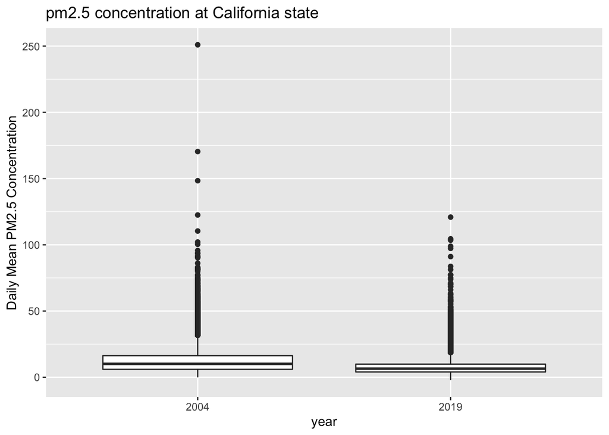

```r
ggplot(data_merge, aes(x = as.factor(year), y= `Daily Mean PM2.5 Concentration`))+
geom_boxplot()+
labs(x = "year",title = "pm2.5 concentration at California state")
```

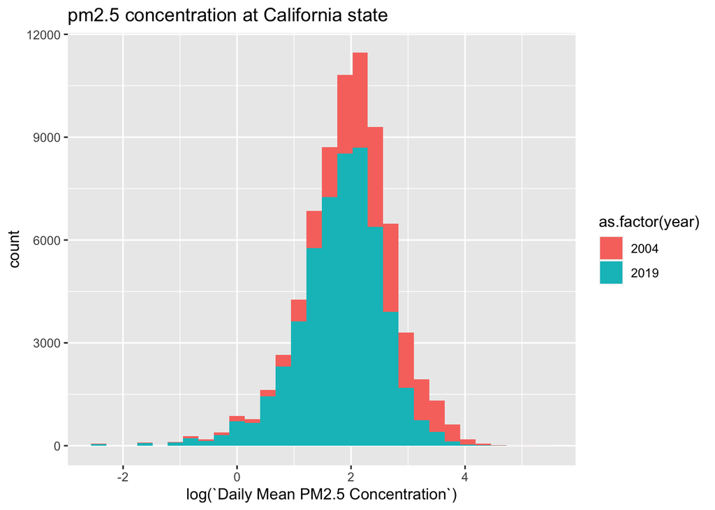

```r
ggplot(data_merge,aes(fill = as.factor(year), x=log(`Daily Mean PM2.5 Concentration`)))+
  geom_histogram()+
labs(title = "pm2.5 concentration at California state")
```

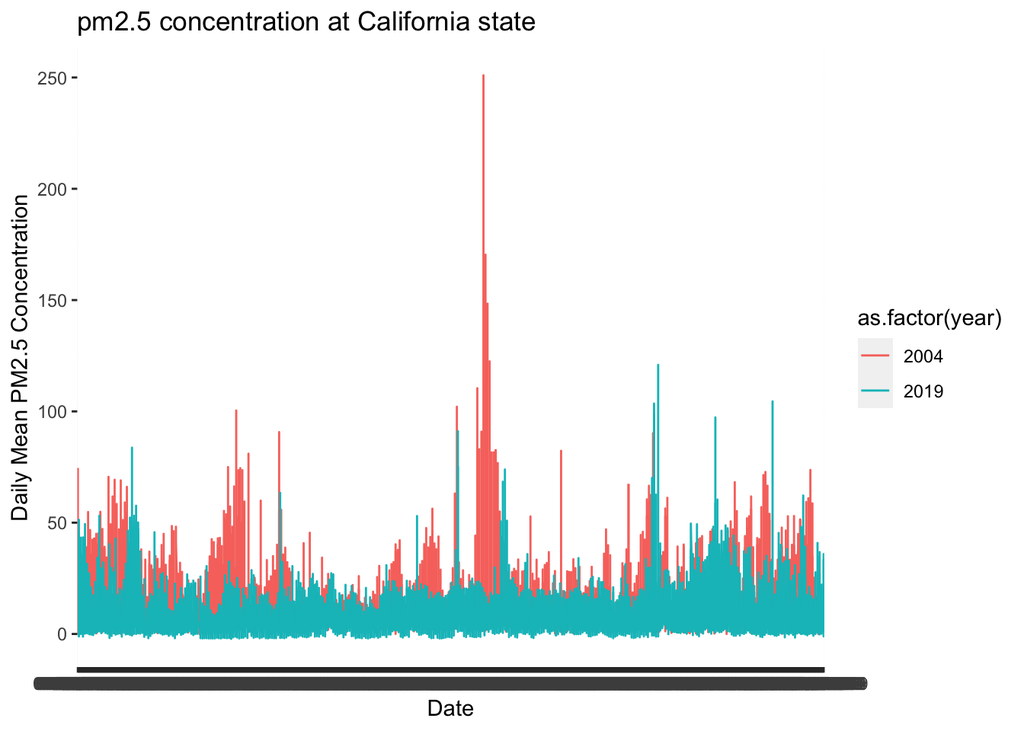

```r
ggplot(data_merge,
       mapping = aes(x=Date, y = `Daily Mean PM2.5 Concentration`,
                     group=year,
                     color=as.factor(year)))+
  geom_line()+
labs(title = "pm2.5 concentration at California state")
```

-When comparing the mean value of pm2.5 concentration between year 2004 and 2019 of California state by boxplot, year 2019 has a lower pm2.5 concentration. -When comparing the mean value of pm2.5 concentration between year 2004 and 2019 of California state by histogram, year 2019 has a lower pm2.5 concentration. -When comparing the mean value of pm2.5 concentration between year 2004 and 2019 of California state by line point, year 2019 has a lower pm2.5 concentration.

```r
# whether the concentration PM2.5 in Los Angeles have decreased over the last 15 years.
data_LA <- data_merge[data_merge$`Site Name`=="Los Angeles-North Main Street",]
dim(data_LA)
```

```
## [1] 1310   21
```

```r
head(data_LA)
```

```
##          Date Source  Site ID POC Daily Mean PM2.5 Concentration    UNITS
## 1: 01/01/2004    AQS 60371103   1                           42.1 ug/m3 LC
## 2: 01/02/2004    AQS 60371103   1                           25.3 ug/m3 LC
## 3: 01/03/2004    AQS 60371103   1                            4.8 ug/m3 LC
## 4: 01/07/2004    AQS 60371103   1                           28.1 ug/m3 LC
## 5: 01/08/2004    AQS 60371103   1                           36.2 ug/m3 LC
## 6: 01/09/2004    AQS 60371103   1                           29.6 ug/m3 LC
##    DAILY_AQI_VALUE                     Site Name DAILY_OBS_COUNT
## 1:             117 Los Angeles-North Main Street               1
## 2:              79 Los Angeles-North Main Street               1
## 3:              20 Los Angeles-North Main Street               1
## 4:              85 Los Angeles-North Main Street               1
## 5:             103 Los Angeles-North Main Street               1
## 6:              88 Los Angeles-North Main Street               1
##    PERCENT_COMPLETE AQS_PARAMETER_CODE       AQS_PARAMETER_DESC CBSA_CODE
```

[output cut: 20 more lines]

```r
data_LA %>%
  group_by(year) %>%
  summarize(pm2.5_mean=mean(`Daily Mean PM2.5 Concentration`), pm2.5_sd=sd(`Daily Mean PM2.5 Concentration`))
```

```
## # A tibble: 2 x 3
##    year pm2.5_mean pm2.5_sd
##   <dbl>      <dbl>    <dbl>
## 1  2004       20.1    11.3
## 2  2019       11.7     5.46
```

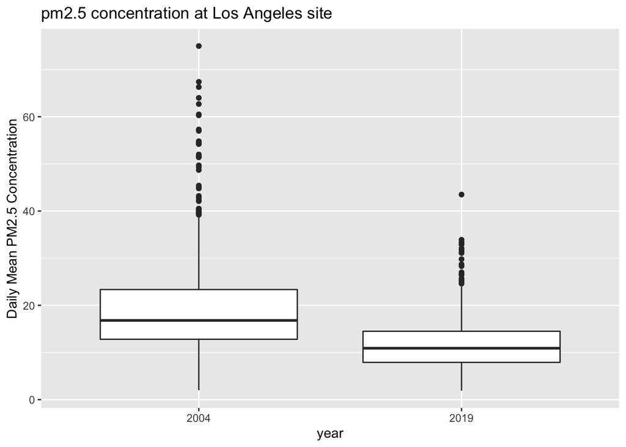

```r
ggplot(data_LA, aes(x = as.factor(year), y= `Daily Mean PM2.5 Concentration`))+
geom_boxplot()+
labs(x = "year",title = "pm2.5 concentration at Los Angeles site")
```

-Extract the Los Angeles data from dara_merge frame. There are 1310 observations and 21 variables. The mean pm2.5 concentration of LA in year 2004 is 20.05, sd is 11.31. The mean pm2.5 concentration in year 2019 is 11.71, sd is 5.46. The statistical result shows that the pm2.5 concentration of LA in year 2019 is lower than year 2004. -When comparing the mean value of pm2.5 concentration of Los Angeles between year 2004 and 2019 by boxplot, year 2019 has a lower pm2.5 concentration.